# PSY 8712 Week 8 Project

Patrick McGonagle

2026-03-20

# Reproducible Image and Online Resources

An image of this project as of *2026-03-23* can be accessed by [clicking this link](https://mybinder.org/v2/gh/mcgon046-max/psy8712-week8/HEAD?urlpath=rstudio)

# Script Settings and Resources

```r
setwd(dirname(rstudioapi::getActiveDocumentContext()$path)) # Working Directory
library(tidyverse)
library(knitr)
```

# Data Import and Cleaning

This is where the data was imported and cleaned. Time variables were coerced into Posix, factor variables were re-coded according codebook, question 5 was reverse coded, new variables were created for subsequent visualization.

```r
week8_tbl <- read_csv("../data/week3.csv") |>
  mutate(timeStart = ymd_hms(timeStart),
         timeEnd = ymd_hms(timeEnd),
         condition = fct_recode(condition,"Block A" = "A", "Block B" = "B","Control" = "C"),
         gender = fct_recode(gender, "Male" = "M", "Female" = "F"),
         q5 = 6 - q5,
         m_q1_q6 = rowMeans(pick(q1:q6), na.rm = TRUE),
         m_q8_q10 = rowMeans(pick(q8:q10), na.rm = TRUE))
```

# Visualization

Data for the first six responses is shown and the mean scores of Q8–Q10 were regressed on the mean scores of Q1–Q6.

Responses for Questions 1 through 6

| q1 | q2 | q3 | q4 | q5 | q6 |
| --- | --- | --- | --- | --- | --- |
| 5 | 4 | 4 | 1 | 2 | 1 |
| 2 | 4 | 3 | 1 | 3 | 1 |
| 5 | 5 | 2 | 1 | 5 | 1 |
| 4 | 3 | 4 | 2 | 4 | 1 |
| 3 | 1 | 3 | 5 | 2 | 1 |
| 4 | 3 | 2 | 3 | 3 | 1 |
| 2 | 4 | 1 | 3 | 1 | 1 |
| 4 | 2 | 5 | 1 | 1 | 1 |
| 2 | 5 | 3 | 4 | 2 | 1 |
| 3 | 4 | 2 | 4 | 5 | 1 |
| 5 | 2 | 3 | 1 | 5 | 1 |
| 3 | 1 | 3 | 5 | 4 | 1 |
| 5 | 5 | 2 | 3 | 4 | 1 |
| 1 | 3 | 5 | 4 | 2 | 1 |
| 4 | 1 | 5 | 1 | 1 | 1 |
| 1 | 3 | 2 | 4 | 5 | 3 |
| 2 | 5 | 4 | 3 | 4 | 1 |
| 4 | 4 | 1 | 3 | 5 | 1 |
| 2 | 3 | 1 | 1 | 4 | 1 |
| 3 | 1 | 2 | 2 | 1 | 1 |
| 3 | 4 | 3 | 3 | 5 | 1 |
| 3 | 1 | 1 | 2 | 3 | 1 |
| 5 | 4 | 4 | 2 | 5 | 1 |
| 5 | 2 | 1 | 2 | 4 | 4 |
| 3 | 3 | 1 | 4 | 5 | 1 |
| 5 | 1 | 3 | 4 | 5 | 1 |
| 2 | 4 | 5 | 4 | 2 | 1 |
| 2 | 4 | 5 | 5 | 3 | 1 |
| 5 | 5 | 3 | 2 | 4 | 1 |
| 1 | 4 | 2 | 4 | 2 | 1 |
| 4 | 1 | 4 | 5 | 1 | 1 |
| 3 | 4 | 3 | 2 | 1 | 1 |
| 3 | 5 | 5 | 5 | 5 | 5 |
| 3 | 1 | 5 | 5 | 2 | 1 |
| 3 | 1 | 2 | 4 | 5 | 1 |
| 3 | 3 | 1 | 1 | 1 | 1 |
| 4 | 2 | 2 | 5 | 1 | 1 |
| 1 | 3 | 3 | 5 | 4 | 1 |
| 5 | 4 | 3 | 3 | 1 | 1 |
| 5 | 1 | 5 | 2 | 2 | 1 |
| 3 | 3 | 4 | 1 | 2 | 1 |
| 5 | 4 | 1 | 1 | 2 | 1 |
| 4 | 5 | 3 | 2 | 2 | 1 |
| 4 | 1 | 3 | 1 | 2 | 1 |
| 5 | 3 | 3 | 5 | 5 | 1 |
| 1 | 4 | 2 | 2 | 1 | 1 |
| 2 | 1 | 1 | 3 | 1 | 1 |
| 4 | 1 | 5 | 2 | 4 | 1 |
| 4 | 2 | 3 | 1 | 3 | 1 |

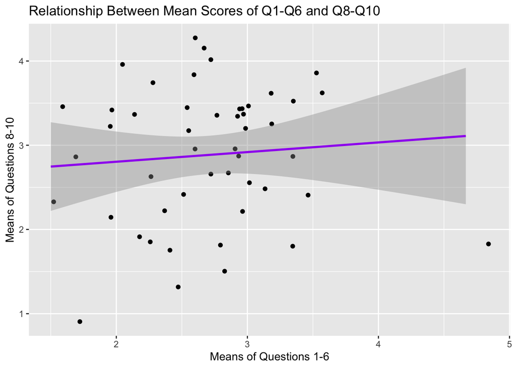

# Analysis

In this code, a pearson correlation test is run on the previously visualized variables. Afterwards, a reproducible paragraph is generated and can be augmented by new values.

```r
# Correlation test between mean scores
cor <- week8_tbl |>
  cor.test(formula = ~ m_q1_q6 + m_q8_q10, data = _)

# Correlation value
cor_val <- cor$estimate

# P value
p_val <- cor$p.value
```

After running a Pearson correlation test on the mean scores of Q1-Q6 and Q8-Q10, a correlation was estimated at .08 with a p-value of .563. This p-value indicates that the probability of observing this correlation by random chance is exceptionally high and thus, the null hypothesis is not rejected and the evidence points to a non-statistically significant relationship between these values.

# Data Export

Here the variables to be used in the Shiny app are selected, and a new data det is generated.

```r
week8_tbl |>
  select(gender, timeStart, m_q1_q6, m_q8_q10) |>
  write_csv("../data/shiny_data.csv")
```